# Project Foundations for Data Science: FoodHub Data Analysis

**Marks: 60**

### Context

The number of restaurants in New York is increasing day by day. Lots of students and busy professionals rely on those restaurants due to their hectic lifestyles. Online food delivery service is a great option for them. It provides them with good food from their favorite restaurants. A food aggregator company FoodHub offers access to multiple restaurants through a single smartphone app.

The app allows the restaurants to receive a direct online order from a customer. The app assigns a delivery person from the company to pick up the order after it is confirmed by the restaurant. The delivery person then uses the map to reach the restaurant and waits for the food package. Once the food package is handed over to the delivery person, he/she confirms the pick-up in the app and travels to the customer's location to deliver the food. The delivery person confirms the drop-off in the app after delivering the food package to the customer. The customer can rate the order in the app. The food aggregator earns money by collecting a fixed margin of the delivery order from the restaurants.

### Objective

The food aggregator company has stored the data of the different orders made by the registered customers in their online portal. They want to analyze the data to get a fair idea about the demand of different restaurants which will help them in enhancing their customer experience. Suppose you are hired as a Data Scientist in this company and the Data Science team has shared some of the key questions that need to be answered. Perform the data analysis to find answers to these questions that will help the company to improve the business.

### Data Description

The data contains the different data related to a food order. The detailed data dictionary is given below.

### Data Dictionary

- order_id: Unique ID of the order
- customer_id: ID of the customer who ordered the food
- restaurant_name: Name of the restaurant
- cuisine_type: Cuisine ordered by the customer
- cost: Cost of the order
- day_of_the_week: Indicates whether the order is placed on a weekday or weekend (The weekday is from Monday to Friday and the weekend is Saturday and Sunday)
- rating: Rating given by the customer out of 5
- food_preparation_time: Time (in minutes) taken by the restaurant to prepare the food. This is calculated by taking the difference between the timestamps of the restaurant's order confirmation and the delivery person's pick-up confirmation.
- delivery_time: Time (in minutes) taken by the delivery person to deliver the food package. This is calculated by taking the difference between the timestamps of the delivery person's pick-up confirmation and drop-off information

### Let us start by importing the required libraries

```python
# import libraries for data manipulation
import numpy as np
import pandas as pd

# import libraries for data visualization
import matplotlib.pyplot as plt
import seaborn as sns
```

### Understanding the structure of the data

```python
from google.colab import drive
drive.mount('/content/drive/')
```

```python
# read the data
df = pd.read_csv('/content/drive/MyDrive/MIT Data Science/Week 2 Statistics/Case Study FoodHub/foodhub_order.csv')
# returns the first 5 rows
df.head()
```

|  | order_id | customer_id | restaurant_name | cuisine_type | cost_of_the_order | day_of_the_week | rating | food_preparation_time | delivery_time |
| --- | --- | --- | --- | --- | --- | --- | --- | --- | --- |
| 0 | 1477147 | 337525 | Hangawi | Korean | 30.75 | Weekend | Not given | 25 | 20 |
| 1 | 1477685 | 358141 | Blue Ribbon Sushi Izakaya | Japanese | 12.08 | Weekend | Not given | 25 | 23 |
| 2 | 1477070 | 66393 | Cafe Habana | Mexican | 12.23 | Weekday | 5 | 23 | 28 |
| 3 | 1477334 | 106968 | Blue Ribbon Fried Chicken | American | 29.20 | Weekend | 3 | 25 | 15 |
| 4 | 1478249 | 76942 | Dirty Bird to Go | American | 11.59 | Weekday | 4 | 25 | 24 |

#### Observations:

The DataFrame has 9 columns as mentioned in the Data Dictionary. Data in each row corresponds to the order placed by a customer.

### **Question 1:** How many rows and columns are present in the data? [0.5 mark]

```python
df.shape
```

```
(1898, 9)
```

#### Observations:

The data frame has 1898 rows and 9 columns.

### **Question 2:** What are the datatypes of the different columns in the dataset? (The info() function can be used) [0.5 mark]

```python
# We use info() to print a concise summary of the DataFrame.

df.info()
```

```
<class 'pandas.core.frame.DataFrame'>
RangeIndex: 1898 entries, 0 to 1897
Data columns (total 9 columns):
 #   Column                 Non-Null Count  Dtype
---  ------                 --------------  -----
 0   order_id               1898 non-null   int64
 1   customer_id            1898 non-null   int64
 2   restaurant_name        1898 non-null   object
 3   cuisine_type           1898 non-null   object
 4   cost_of_the_order      1898 non-null   float64
 5   day_of_the_week        1898 non-null   object
 6   rating                 1898 non-null   object
 7   food_preparation_time  1898 non-null   int64
 8   delivery_time          1898 non-null   int64
dtypes: float64(1), int64(4), object(4)
memory usage: 133.6+ KB
```

#### Observations:

The data frame contains attributes of three different types:

- float
- integer
- object (represents any data structure or value).

**Note:** According to the data dictionary, the restaurant rating is supposed to be a numeric value with a maximum value of 5. In the data frame info, we see that rating is has the type "object". We expect that the column "rating" may contain strings alongside integers. Rating is an important measure of customer experience. Therefore, we will likely have to investigatet this issue and possibly convert these values later on.

### **Question 3:** Are there any missing values in the data? If yes, treat them using an appropriate method. [1 mark]

```python
# With the help of the info() function from Question 2 we can already see that there is no missing data in the data frame.
# We have 1898 rows of data, and each column contains exactly 1898 entries of non-null content. Hence the data frame does not contain any missing data.
# Nonetheless, let's double-check using the isnull().sum() function. This will print the summary of the missing data per column if there is any.

df.isnull().sum()
```

```
order_id                 0
customer_id              0
restaurant_name          0
cuisine_type             0
cost_of_the_order        0
day_of_the_week          0
rating                   0
food_preparation_time    0
delivery_time            0
dtype: int64
```

#### Observations:

There is no missing data in the data frame.

### **Question 4:** Check the statistical summary of the data. What is the minimum, average, and maximum time it takes for food to be prepared once an order is placed? [2 marks]

```python
# Print the statistical summary of the data.
# We use the parameter include to see the summary for the data of each type, i.e. all columns of the input will be included into the output.

df.describe(include='all').T
```

|  | count | unique | top | freq | mean | std | min | 25% | 50% | 75% | max |
| --- | --- | --- | --- | --- | --- | --- | --- | --- | --- | --- | --- |
| order_id | 1898.0 | NaN | NaN | NaN | 1477495.5 | 548.049724 | 1476547.0 | 1477021.25 | 1477495.5 | 1477969.75 | 1478444.0 |
| customer_id | 1898.0 | NaN | NaN | NaN | 171168.478398 | 113698.139743 | 1311.0 | 77787.75 | 128600.0 | 270525.0 | 405334.0 |
| restaurant_name | 1898 | 178 | Shake Shack | 219 | NaN | NaN | NaN | NaN | NaN | NaN | NaN |
| cuisine_type | 1898 | 14 | American | 584 | NaN | NaN | NaN | NaN | NaN | NaN | NaN |
| cost_of_the_order | 1898.0 | NaN | NaN | NaN | 16.498851 | 7.483812 | 4.47 | 12.08 | 14.14 | 22.2975 | 35.41 |
| day_of_the_week | 1898 | 2 | Weekend | 1351 | NaN | NaN | NaN | NaN | NaN | NaN | NaN |
| rating | 1898 | 4 | Not given | 736 | NaN | NaN | NaN | NaN | NaN | NaN | NaN |
| food_preparation_time | 1898.0 | NaN | NaN | NaN | 27.37197 | 4.632481 | 20.0 | 23.0 | 27.0 | 31.0 | 35.0 |
| delivery_time | 1898.0 | NaN | NaN | NaN | 24.161749 | 4.972637 | 15.0 | 20.0 | 25.0 | 28.0 | 33.0 |

#### Observations:

The minimum time it takes to prepare the food is 20.0 minutes. The average time to prepare the food is 27.37197 minutes. The maximum time to prepare the food is 35 minutes, once the order is placed.

### **Question 5:** How many orders are not rated? [1 mark]

```python
# This information is already available in the data summary above. "Not given" happens to be the most frequent value in the column "rating".
# Therefore the statistics for this value is already given - 736.
# Nonetheless, let's use the function value_counts() to see how often "Not given" occurs in the column "rating" of the data frame.

df["rating"].value_counts()["Not given"]
```

```
736
```

#### Observations:

736 orders in the data frame are not rated. As noted above, Rating is an important measure of customer experience. Therefore, we will likely have to investigatet this issue and possibly convert these values later on.

### Exploratory Data Analysis (EDA)

### **Question 6:** Explore all the variables and provide observations on their distributions. (Generally, histograms, boxplots, countplots, etc. are used for univariate exploration.) [9 marks]

### Oder ID

```python
# Checking the unique order ID

df['order_id'].nunique()
```

```
1898
```

### Customer ID

```python
# Checking the number of unique customer ID's

df['customer_id'].nunique()
```

```
1200
```

### Restaurant name

```python
# Checking the number of unique restaurant names
df['restaurant_name'].nunique()
```

```
178
```

#### **Note**: we do not expect to draw any meaningful insights from the distributions of the values order_id, customer_id, and restaurant_name. Therefore, we will not investigate these distributions further.

### Cuisine type

```python
# Checking the number of unique cuisine types.
```

```python
df['cuisine_type'].nunique()
```

```
14
```

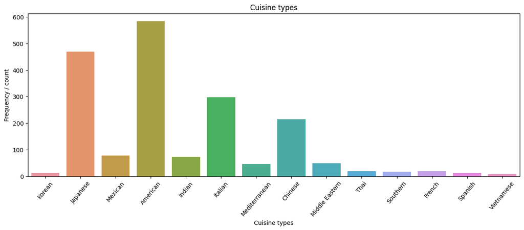

```python
# Cuisine type is a discrete variable. We can use a bar graph to visualize the distribution.
# Let's customize this visualization to get a clearer picture.

plt.figure(figsize= (15, 5))
plt.title('Cuisine types')
sns.countplot(data = df, x = 'cuisine_type')
plt.xlabel('Cuisine types')
plt.xticks(rotation = 50)
plt.ylabel('Frequency / count')
plt.show()
```

#### Observations:

We can see clear preferences towards cetrain types of cuisine among the users. The most preferred typed of cuisine are American, Japanese, Italian and Chinese. This may or may not be an indicator of a better customer experience of the serving restaurants. At the same time, it may also be explaned by a possible bias within the population of users or other factors.

### Cost of the order

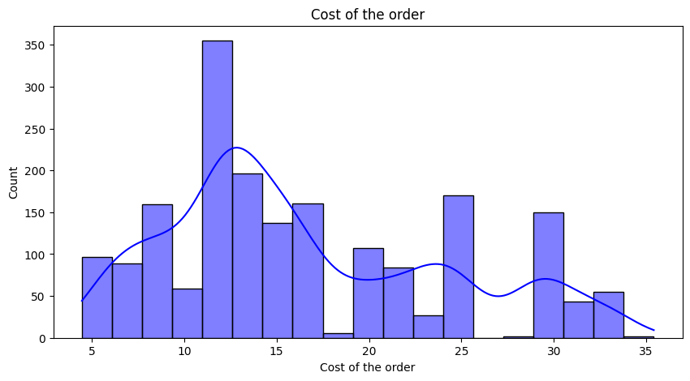

```python
# cost_of_the _order is a continious variable. Therefore we use a histogram to visualize the distribution.


plt.figure(figsize= (10,5))
plt.title("Cost of the order")
plt.xlabel("Cost of the order")
sns.histplot(data=df, x='cost_of_the_order', kde=True, color = 'blue')
plt.show()
```

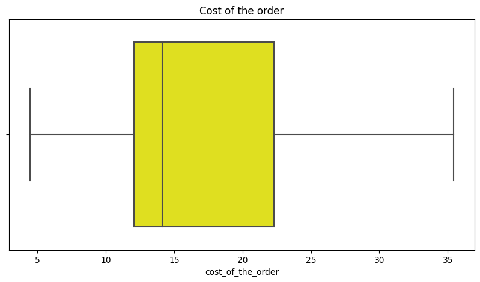

```python
# The distribution appears to be right skewed. We can use a box plot to show the skewness through displaying the data quartiles.

# Creating and customizing a boxplot with seaborn.

plt.figure(figsize= (10, 5))
plt.title('Cost of the order')
plt.xlabel('Cost of the order')
sns.boxplot(data=df, x='cost_of_the_order', color='yellow');
```

```python
# In this boxplot, we can clearly see that the distribution is positively skewed. Also let's note that there are no outliers.
```

#### Observations:

The relatively small range of the distribution and the absence of outliers are good indicators of the comparability of the restaurants. We may conclude that all restaurants in the population operate within a relatievely similar price range. At the same time we may not forget, that the cost of order may be influence by various factors of which we have no data (e.g. size of the ordering party).

### Day of the week

```python
# Checking the number of unique values in this column.

df['day_of_the_week'].nunique()
```

```
2
```

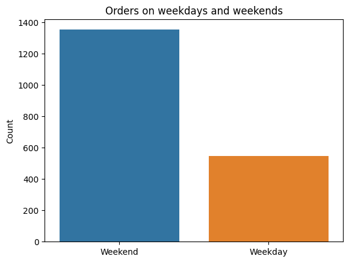

```python
# As declared in the data dictionary, the data frame contains two unique values to distinguish whether the order was made on a weekday or on a weekend.
# A boxplot will help us visualize the distribution to gain further insights.

sns.countplot(data=df, x='day_of_the_week')
plt.title('Orders on weekdays and weekends')
plt.xlabel('')
plt.ylabel('Count');
```

#### Observations:

We observe a very clear prevalence of the orders on the weekeds.

### Rating

```python
#  Checking the number of unique values in this column.

df['rating'].nunique()
```

```
4
```

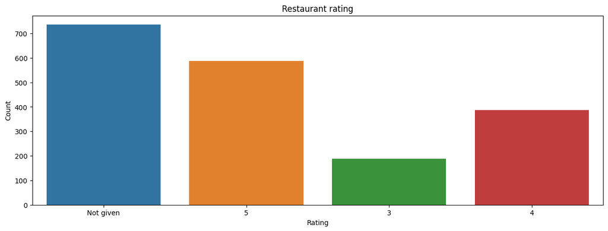

```python
# rating is a discrete variable. We can use a bar chart to visualize the ditribution.

plt.figure(figsize=(15,5))
sns.countplot(data=df, x='rating')
plt.title('Restaurant rating')
plt.xlabel('Rating')
plt.ylabel('Count');
```

#### Observations:

The most popular value is "not given". This may be an indication of some improvement potential in the evaluation mechanism.

### Food preparation time

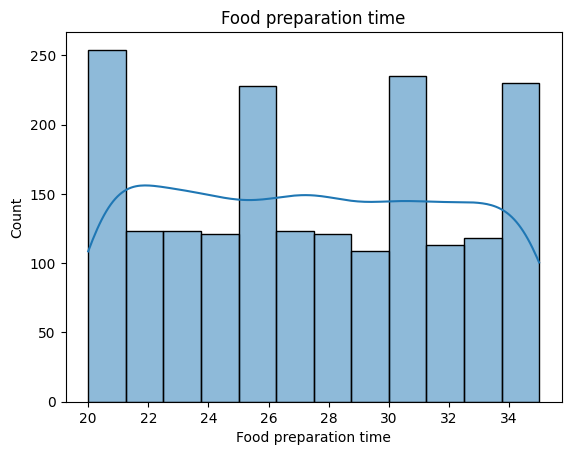

```python
# food_preparation_time is a discrete variable. We can use a bar chart to visualize the ditribution.
# At the same time, we will use a boxplot to vizualize this distrinbution and get a clear visual 5-point-summary of the distribution.
sns.histplot(data=df, x='food_preparation_time', kde=True)
plt.title('Food preparation time')
plt.xlabel('Food preparation time')
plt.ylabel('Count');
```

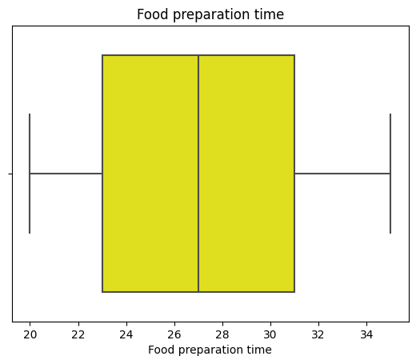

```python
sns.boxplot(data=df, x='food_preparation_time', color='yellow')
plt.title('Food preparation time')
plt.xlabel('Food preparation time');
```

#### Observations:

We observe a relatively small range of the food preparation time with a few clear peaks. In the absense of further data, this may be an indication of standardized processes during the preparation as well as some popular party sizes (e.g. 2, 4, 6, or 8 people).

### Delivery time

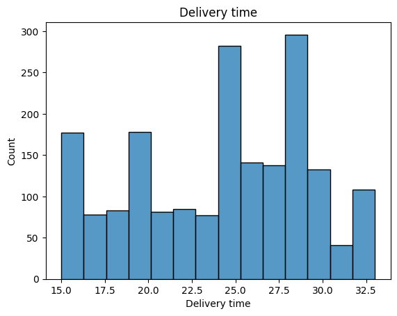

```python
# food_preparation_time is a discrete variable. We can use a bar chart to visualize the ditribution.
# At the same time, we will use a boxplot to vizualize this distrinbution and get a clear visual 5-point-summary of the distribution.
sns.histplot(data=df, x='delivery_time')
plt.title('Delivery time')
plt.xlabel('Delivery time')
plt.ylabel('Count');
```

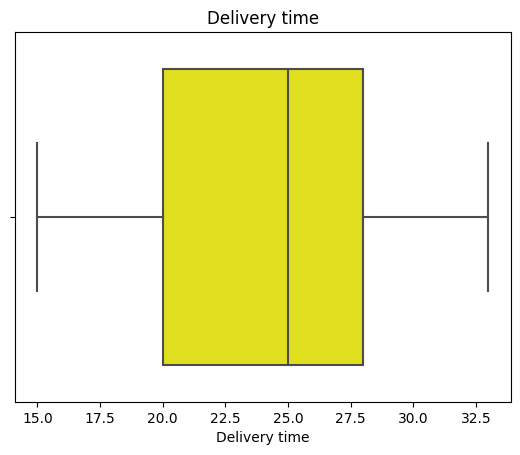

```python
sns.boxplot(data=df, x='delivery_time', color='yellow')
plt.title('Delivery time')
plt.xlabel('Delivery time');
```

#### Observations:

We observe a relatively small range of the delivery time.

### **Question 7**: Which are the top 5 restaurants in terms of the number of orders received? [1 mark]

```python
df['restaurant_name'].value_counts().head(5)
```

```
Shake Shack                  219
The Meatball Shop            132
Blue Ribbon Sushi            119
Blue Ribbon Fried Chicken     96
Parm                          68
Name: restaurant_name, dtype: int64
```

#### Observations:

The number of orders received is a very important measure of the customer experience. We observe the customer behavior - ordering - that could be interpreted as a signal of positive customer experience. Among the 5 top favorites, Shake Shack appears to be the most popular leaving a significant gap to the runner-up.

### **Question 8**: Which is the most popular cuisine on weekends? [1 mark]

```python
weekend_favorite = df[df['day_of_the_week'] == 'Weekend']['cuisine_type'].value_counts().head(1)
print(weekend_favorite)
```

```
American    415
Name: cuisine_type, dtype: int64
```

#### Observations:

This observation confirms one of the previous observations that American is the most popular cuisine type: overall as well as on the weekends.

### **Question 9**: What percentage of the orders cost more than 20 dollars? [2 marks]

```python
orders_greater_20 = df[df['cost_of_the_order']>20]
orders_greater_20.shape
```

```
(555, 9)
```

```python
print(orders_greater_20.shape[0]) # Number of orders with the cost of the order greater than 20 USD.
```

```
555
```

```python
# Percentage of such orders in the data set
percentage = orders_greater_20.shape[0] / df.shape[0] * 100
print(round(percentage, 2), '% of all orders cost more than 20 dollars.')
```

```
29.24 % of all orders cost more than 20 dollars.
```

#### Observations:

The value of 20 dollars lies above the mean, in the third quartile. Therefore, it is not surprising that almost a third of all the orders lies above that value. This observation is in line with the right skewness of the distribution.

### **Question 10**: What is the mean order delivery time? [1 mark]

```python
mean_delivery_time = df['delivery_time'].mean()
print("The mean order delivery time is", round(mean_delivery_time,2), "minutes.")
```

```
The mean order delivery time is 24.16 minutes.
```

#### Observations:

Also an expected value given the previous observation of the distribution.

### **Question 11:** The company has decided to give 20% discount vouchers to the top 3 most frequent customers. Find the IDs of these customers and the number of orders they placed. [1 mark]

```python
df['customer_id'].value_counts().head(3)
```

```
52832    13
47440    10
83287     9
Name: customer_id, dtype: int64
```

#### Observations:

The top 3 most frequent customers have placed 13, 10 and 9 orders.

### **Question 12**: Perform a multivariate analysis to explore relationships between the important variables in the dataset. (It is a good idea to explore relations between numerical variables as well as relations between numerical and categorical variables) [10 marks]

```python
# We have the following categorical and numerical values in the data set:
# Categorical: cuisine_type, day_of_the_week
# Numerical: cost_of_the_order, rating, food_preratation_time, delivery_time

# It makes sense to explore whether and how rating of a restaurant is influenced by the cost of the order, food preparation and delivery time.
# We assume that cuisine type is a matter of individual taste. While it may well influence the rating, we believe that it cannot be objectivized.
# Following the same logic, we will explore the relationship between cuisine type and cost of the order as well as cuisine type and food preparation time.
# We will also look at tg relationship between the day of the week and the delivery time, assuming that the influence of the day of the week on cuisine type, cost of the order, rating and food preparation time is rather irrelevant.
```

### Cuisine type and cost of the order

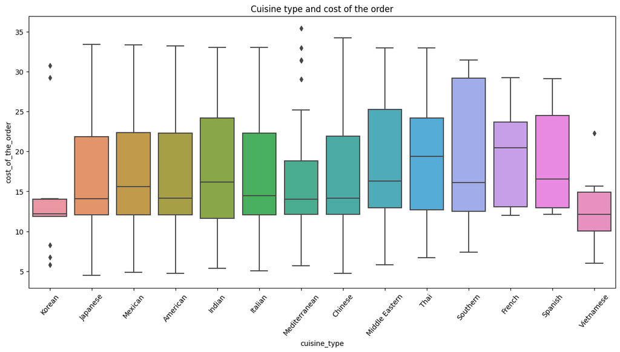

```python
plt.figure(figsize=(15,7))
sns.boxplot(x = 'cuisine_type', y = 'cost_of_the_order', data = df)
plt.xticks(rotation = 50)
plt.title('Cuisine type and cost of the order')
plt.show();
```

### Cuisine type and food preparation time

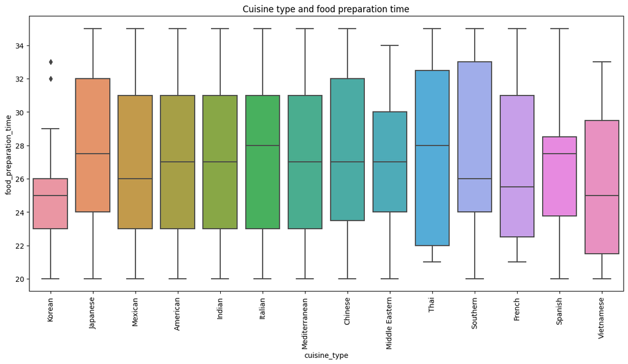

```python
plt.figure(figsize=(15,7))
sns.boxplot(x = 'cuisine_type', y = 'food_preparation_time', data = df)
plt.xticks(rotation = 90)
plt.title('Cuisine type and food preparation time')
plt.show();
```

### Day of the week and delivery time

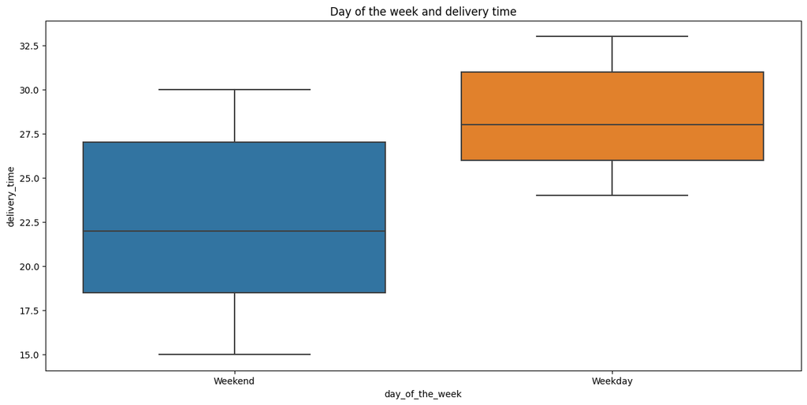

```python
plt.figure(figsize=(15,7))
sns.boxplot(x = 'day_of_the_week', y = 'delivery_time', data = df)
plt.title('Day of the week and delivery time')
plt.show();
```

```python
## When working with the variable rating, we need to take into account that certain orders were not rated.
## To perform the analysis, we will eliminate the non rated orders and convert the variable rating into the type integer.

df_altered = df[df['rating'] != 'Not given']
df_altered['rating'] = df_altered['rating'].astype(int)
```

### Rating and cost of the order

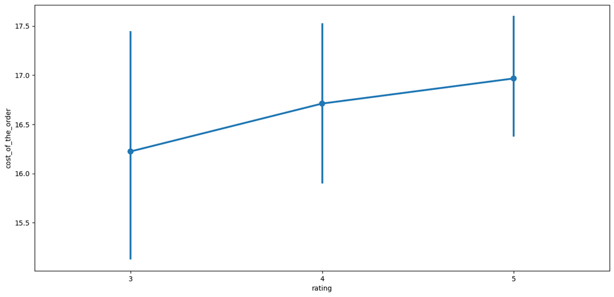

```python
plt.figure(figsize=(15, 7))
sns.pointplot(x = 'rating', y = 'cost_of_the_order', data = df_altered)
plt.show();
```

### Rating and food preparation time

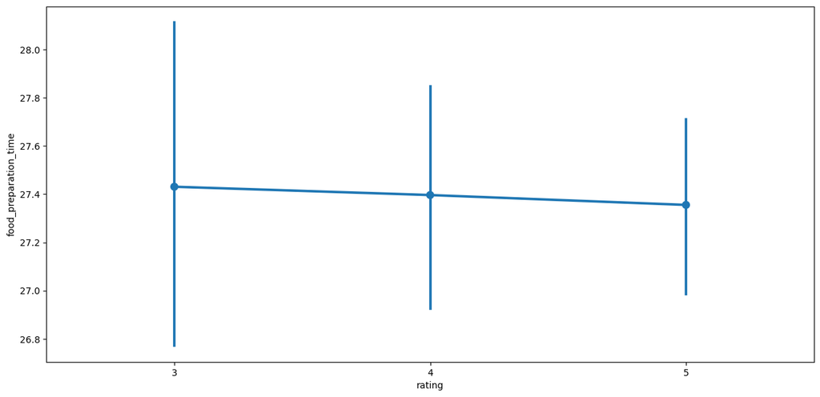

```python
plt.figure(figsize=(15, 7))
sns.pointplot(x = 'rating', y = 'food_preparation_time', data = df_altered)
plt.show();
```

### Rating and delivery time

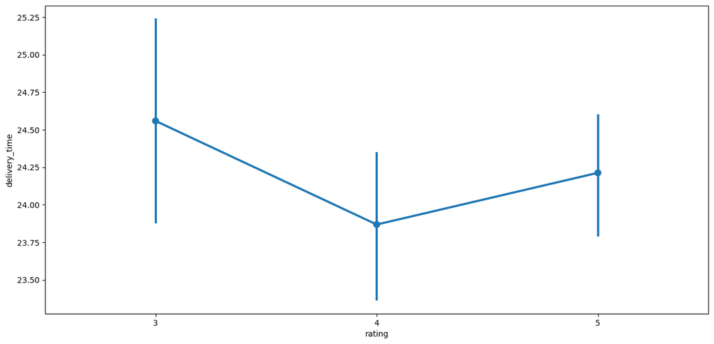

```python
plt.figure(figsize=(15, 7))
sns.pointplot(x = 'rating', y = 'delivery_time', data = df_altered)
plt.show();
```

### Correlation and heatmap

```python
df[['cost_of_the_order','rating','food_preparation_time','delivery_time']].corr()
```

[output not shown]

[figure not shown]

```python
sns.heatmap(data=df[['cost_of_the_order','rating','food_preparation_time','delivery_time']].corr(), annot = True, cmap = 'coolwarm')
plt.show();
```

### **Question 13:** The company wants to provide a promotional offer in the advertisement of the restaurants. The condition to get the offer is that the restaurants must have a rating count of more than 50 and the average rating should be greater than 4. Find the restaurants fulfilling the criteria to get the promotional offer. [3 marks]

```python
# Algorythm:
# Step 1: create a subset of the data frame with restaurant namens and ratings that only contains rows where restaurant has a rating.
# Step 2: compute the rating count of the restaurants and filter the restaurants with the rating count greater than 50
# Step 3: compute the mean rating of the restaurants and filter the restaurants with the mean rating greater 4
# Step 4: merge the data frames with the filtered results by the name of the restaurants and print the restult
```

```python
# Step 1: create a subset of the data frame with restaurant names and ratings that only contains rows where restaurant has a rating.
df_hasrating = df[['restaurant_name', 'rating']]

## A number of restaurants are not rated. Therefore their rating count and mean rating cannot be calculated.
## We eliminate those from the data frame and convert the remaining values into integers.
df_hasrating = df_hasrating[df_hasrating['rating'] != 'Not given']
df_hasrating.head()
```

|  | restaurant_name | rating |
| --- | --- | --- |
| 2 | Cafe Habana | 5 |
| 3 | Blue Ribbon Fried Chicken | 3 |
| 4 | Dirty Bird to Go | 4 |
| 5 | Tamarind TriBeCa | 3 |
| 7 | Barbounia | 3 |

```python
### Check the type of values in the data frame.
df_hasrating.dtypes
```

```
restaurant_name    object
rating             object
dtype: object
```

```python
### Convert the values in the column "rating" into integers.
df_hasrating['rating'] = df_hasrating['rating'].astype(int)
df_hasrating.dtypes
```

```
restaurant_name    object
rating              int64
dtype: object
```

```python
# Step 2: compute the rating count of the restaurants and filter the restaurants with the rating count greater than 50.

## First, we calculate the cumulative rating of the restaurants.
df_ratingcount = df_hasrating.groupby(['restaurant_name'])['rating'].count().sort_values(ascending = False).reset_index()
df_ratingcount.head()
```

|  | restaurant_name | rating |
| --- | --- | --- |
| 0 | Shake Shack | 133 |
| 1 | The Meatball Shop | 84 |
| 2 | Blue Ribbon Sushi | 73 |
| 3 | Blue Ribbon Fried Chicken | 64 |
| 4 | RedFarm Broadway | 41 |

```python
## Then, we filter the restaurants with the rating count greater than 50.
df_ratingcount_50 = df_ratingcount[df_ratingcount['rating'] > 50]
df_ratingcount_50.head()
```

|  | restaurant_name | rating |
| --- | --- | --- |
| 0 | Shake Shack | 133 |
| 1 | The Meatball Shop | 84 |
| 2 | Blue Ribbon Sushi | 73 |
| 3 | Blue Ribbon Fried Chicken | 64 |

```python
# Step 3: compute the mean rating of the restaurants and filter the restaurants with the mean rating greater 4.

## Compute the mean rating of the restaurants.
df_meanrating = df_hasrating.groupby(['restaurant_name'])['rating'].mean().sort_values(ascending = False).reset_index()
df_meanrating.head()
```

|  | restaurant_name | rating |
| --- | --- | --- |
| 0 | 'wichcraft | 5.0 |
| 1 | Ravagh Persian Grill | 5.0 |
| 2 | Chola Eclectic Indian Cuisine | 5.0 |
| 3 | Chote Nawab | 5.0 |
| 4 | Junoon | 5.0 |

```python
## Filter the restaurants with the mean rating greater than 4.
df_meanrating_4 = df_meanrating[df_meanrating['rating'] > 4]
df_meanrating_4.head()
```

|  | restaurant_name | rating |
| --- | --- | --- |
| 0 | 'wichcraft | 5.0 |
| 1 | Ravagh Persian Grill | 5.0 |
| 2 | Chola Eclectic Indian Cuisine | 5.0 |
| 3 | Chote Nawab | 5.0 |
| 4 | Junoon | 5.0 |

```python
# Step 4: merge the data frames with the filtered results by the name of the restaurants and print the restult

print(df_ratingcount_50.merge(df_meanrating_4, on = 'restaurant_name'))
```

```
             restaurant_name  rating_x  rating_y
0                Shake Shack       133  4.278195
1          The Meatball Shop        84  4.511905
2          Blue Ribbon Sushi        73  4.219178
3  Blue Ribbon Fried Chicken        64  4.328125
```

#### Observations:

4 restaurants fulfilling the criteria to get the promotional offer. These 4 restaurants in that very order are the most popular choices among the app users. Therefore, our analysis confirms our previous observation that the ordering frequency is a good indicator of positive customer experience.

### **Question 14:** The company charges the restaurant 25% on the orders having cost greater than 20 dollars and 15% on the orders having cost greater than 5 dollars. Find the net revenue generated by the company across all orders. [3 marks]

```python
def revenue(x):
  if x > 20:
    return x*0.25
  elif x > 5:
    return x*0.15
  else:
    return x*0

df['Revenue'] = df['cost_of_the_order'].apply(revenue)
df.head()
```

|  | order_id | customer_id | restaurant_name | cuisine_type | cost_of_the_order | day_of_the_week | rating | food_preparation_time | delivery_time | Revenue |
| --- | --- | --- | --- | --- | --- | --- | --- | --- | --- | --- |
| 0 | 1477147 | 337525 | Hangawi | Korean | 30.75 | Weekend | Not given | 25 | 20 | 7.6875 |
| 1 | 1477685 | 358141 | Blue Ribbon Sushi Izakaya | Japanese | 12.08 | Weekend | Not given | 25 | 23 | 1.8120 |
| 2 | 1477070 | 66393 | Cafe Habana | Mexican | 12.23 | Weekday | 5 | 23 | 28 | 1.8345 |
| 3 | 1477334 | 106968 | Blue Ribbon Fried Chicken | American | 29.20 | Weekend | 3 | 25 | 15 | 7.3000 |
| 4 | 1478249 | 76942 | Dirty Bird to Go | American | 11.59 | Weekday | 4 | 25 | 24 | 1.7385 |

```python
total_revenue = df['Revenue'].sum()
print('The net revenue generated by the company across all orders is', round(total_revenue, 2), 'dollars.')
```

```
The net revenue generated by the company across all orders is 6166.3 dollars.
```

#### Observations:

We do not have enough context to analyse and evaluate the revenue. It would be interesting to look at the development of the revenue over time and investigate various factors influencing it.

### **Question 15:** The company wants to analyze the total time required to deliver the food. What percentage of orders take more than 60 minutes to get delivered from the time the order is placed? (The food has to be prepared and then delivered.) [2 marks]

```python
df['total_time'] = df['food_preparation_time'] + df['delivery_time']
df.head()
```

|  | order_id | customer_id | restaurant_name | cuisine_type | cost_of_the_order | day_of_the_week | rating | food_preparation_time | delivery_time | Revenue | total_time |
| --- | --- | --- | --- | --- | --- | --- | --- | --- | --- | --- | --- |
| 0 | 1477147 | 337525 | Hangawi | Korean | 30.75 | Weekend | Not given | 25 | 20 | 7.6875 | 45 |
| 1 | 1477685 | 358141 | Blue Ribbon Sushi Izakaya | Japanese | 12.08 | Weekend | Not given | 25 | 23 | 1.8120 | 48 |
| 2 | 1477070 | 66393 | Cafe Habana | Mexican | 12.23 | Weekday | 5 | 23 | 28 | 1.8345 | 51 |
| 3 | 1477334 | 106968 | Blue Ribbon Fried Chicken | American | 29.20 | Weekend | 3 | 25 | 15 | 7.3000 | 40 |
| 4 | 1478249 | 76942 | Dirty Bird to Go | American | 11.59 | Weekday | 4 | 25 | 24 | 1.7385 | 49 |

```python
total_time_greater_60 = df[df['total_time']>60]
```

```python
print(total_time_greater_60.shape[0])
```

```
200
```

```python
percentage_total_60 = total_time_greater_60.shape[0] / df.shape[0] * 100
```

```python
print(round(percentage_total_60, 2), '% of all orders take more than 60 minutes to get delivered from the time the order is placed.')
```

```
10.54 % of all orders take more than 60 minutes to get delivered from the time the order is placed.
```

#### Observations:

Considering that 60 minutes or more may be a critical value influencing customer experience, it is worth investigating the reasons for the longer delivery times.

### **Question 16:** The company wants to analyze the delivery time of the orders on weekdays and weekends. How does the mean delivery time vary during weekdays and weekends? [2 marks]

```python
Weekday_mean = df[df['day_of_the_week'] == 'Weekday']['delivery_time'].mean()
print('The mean delivery time on during weekdays is', round(Weekday_mean, 2), 'minutes.')
```

```
The mean delivery time on during weekdays is 28.34 minutes.
```

```python
Weekend_mean = df[df['day_of_the_week'] == 'Weekend']['delivery_time'].mean()
print('The mean delivery time on during weekends is', round(Weekend_mean, 2), 'minutes.')
```

```
The mean delivery time on during weekends is 22.47 minutes.
```

#### Observations:

We have seen previously that that majority or orders are submitted weekends. Therefore it is positive to see that the mean delivery time on the weekends is shorter.

### Conclusion and Recommendations

### **Question 17:** What are your conclusions from the analysis? What recommendations would you like to share to help improve the business? (You can use cuisine type and feedback ratings to drive your business recommendations.) [6 marks]

### Recommendations:

- Assuming that rating is an important measure of customer experience, I recommend investigating this mechanism to understand why so many users prefer not to rate their orders and what could be done to improve the process.
- It appears that ordering behavior is a good indicator of the customer experience. Therefore, to save time and draw quick conclusions, I recommend determining the most popular resaurants by the number of orders.
- The heatmap shows that the rating of the restaurants is very moderately influienced by cost of the order or delivery or preparation time. Therefore, I recommend to investigate further factors that may influence the rating, such as quality of food, offers, etc.